# Project 1- Applied statistics (abhinandan)

### After various EDA and analysis, we came to conclusion that the best bet will be to invest on team 21. this team has shown great potential (has good Won/Played ratio) and since its comparatively new, there won't be any prior investors.

#### Similarly Teams 20 and 19 could also be good bet.

#### Points for Management:

```
1. Teams with high Basket score also have high Basket given score, reflecting less defence capability.
2. Older teams have more skilled players and hence their defence is better.
3. Some teams, although with bad Score, have managed to qualify in finals and hence are runnerup.
```

## Module 3: Project Based

#### 1. Data warehouse:

• Read the CSV file.

```python
df3 = pd.read_csv("DS - Part3 - CompanyX_EU.csv")
```

```python
df3.head(10)
```

|  | Startup | Product | Funding | Event | Result | OperatingState |
| --- | --- | --- | --- | --- | --- | --- |
| 0 | 2600Hz | 2600hz.com | NaN | Disrupt SF 2013 | Contestant | Operating |
| 1 | 3DLT | 3dlt.com | $630K | Disrupt NYC 2013 | Contestant | Closed |
| 2 | 3DPrinterOS | 3dprinteros.com | NaN | Disrupt SF 2016 | Contestant | Operating |
| 3 | 3Dprintler | 3dprintler.com | $1M | Disrupt NY 2016 | Audience choice | Operating |
| 4 | 42 Technologies | 42technologies.com | NaN | Disrupt NYC 2013 | Contestant | Operating |
| 5 | 5to1 | 5to1.com | $19.3M | TC50 2009 | Contestant | Acquired |
| 6 | 8 Securities | 8securities.com | $29M | Disrupt Beijing 2011 | Finalist | Operating |
| 7 | 8020 Media | 8020media.com | NaN | TC40 2007 | Contestant | Operating |
| 8 | About Last Night | aboutlastnight.net | NaN | Disrupt NYC 2012 | Contestant | Operating |
| 9 | Adgregate Markets | adgregate.com | NaN | TC50 2008 | Contestant | Operating |

#### 2. Data exploration:

• Check the datatypes of each attribute.  
• Check for null values in the attributes.

```python
df3.info()
```

```
<class 'pandas.core.frame.DataFrame'>
RangeIndex: 662 entries, 0 to 661
Data columns (total 6 columns):
 #   Column          Non-Null Count  Dtype
---  ------          --------------  -----
 0   Startup         662 non-null    object
 1   Product         656 non-null    object
 2   Funding         448 non-null    object
 3   Event           662 non-null    object
 4   Result          662 non-null    object
 5   OperatingState  662 non-null    object
dtypes: object(6)
memory usage: 31.2+ KB
```

```python
df3.describe().T
```

|  | count | unique | top | freq |
| --- | --- | --- | --- | --- |
| Startup | 662 | 662 | Jukedeck | 1 |
| Product | 656 | 656 | truecar.com | 1 |
| Funding | 448 | 240 | $1M | 17 |
| Event | 662 | 26 | TC50 2008 | 52 |
| Result | 662 | 5 | Contestant | 488 |
| OperatingState | 662 | 4 | Operating | 465 |

```python
df3.isnull().any()
```

```
Startup           False
Product            True
Funding            True
Event             False
Result            False
OperatingState    False
dtype: bool
```

```python
df3.isnull().sum()
```

```
Startup             0
Product             6
Funding           214
Event               0
Result              0
OperatingState      0
dtype: int64
```

- We have total of 662 entries present in our data-set.
- data type of all the variables is OBJECT.
- We have null values present in PRODUCT and FUNDING columns.

#### 3. Data preprocessing & visualisation:

- Drop the null values.
- Convert the ‘Funding’ features to a numerical value.
- Plot box plot for funds in million.
- Get the lower fence from the box plot.
- Check number of outliers greater than upper fence.
- Drop the values that are greater than upper fence.
- Plot the box plot after dropping the values.
- Check frequency of the OperatingState features classes.
- Plot a distribution plot for Funds in million.
- Plot distribution plots for companies still operating and companies that closed.

```python
#dropping values from where the values are- null values
df3.dropna(how='any',inplace=True)
df3.info()
```

```
<class 'pandas.core.frame.DataFrame'>
Int64Index: 446 entries, 1 to 661
Data columns (total 6 columns):
 #   Column          Non-Null Count  Dtype
---  ------          --------------  -----
 0   Startup         446 non-null    object
 1   Product         446 non-null    object
 2   Funding         446 non-null    object
 3   Event           446 non-null    object
 4   Result          446 non-null    object
 5   OperatingState  446 non-null    object
dtypes: object(6)
memory usage: 24.4+ KB
```

```python
df3.sample(10)
```

|  | Startup | Product | Funding | Event | Result | OperatingState |
| --- | --- | --- | --- | --- | --- | --- |
| 243 | Heatworks Technology | myheatworks.com | $7.2M | Disrupt NYC 2014 | Runner up | Operating |
| 326 | LyteShot | lyteshot.com | $635K | Hardware Battlefield 2015 | Contestant | Operating |
| 595 | Trutap | trutap.com | $14.5M | TC40 2007 | Contestant | Closed |
| 150 | Donay | donay.com | $160K | Disrupt NYC 2013 | Contestant | Closed |
| 120 | Compass Labs | compasslabs.com | $12M | Disrupt NYC 2010 | Contestant | Closed |
| 127 | Crate.io | crate.io | $8.1M | Disrupt EU 2014 | Winner | Operating |
| 249 | HowFactory | howfactory.com | $195K | Disrupt NY 2015 | Contestant | Operating |
| 83 | Buyou | buyouapp.com | $20K | Disrupt NYC 2012 | Audience choice | Operating |
| 86 | CallApp | callapp.com | $5M | Disrupt NYC 2012 | Contestant | Operating |
| 231 | HackerRank | hackerrank.com | $24.2M | Disrupt SF 2012 | Contestant | Operating |

```python
# converting Funding to numerical data:

df3["Funding"] = df3['Funding'].str.replace(',', '')
df3["Funding"] = df3['Funding'].str.replace('$', '')


df3.Funding = (df3.Funding.replace(r'[KMB]+$', '', regex=True).astype(float) *
          df3.Funding.str.extract(r'[\d\.]+([KMB]+)', expand=False).fillna(1)
          .replace(['K','M','B'], [10**3, 10**6, 10**9]).astype(int))
```

```python
df3
```

|  | Startup | Product | Funding | Event | Result | OperatingState |
| --- | --- | --- | --- | --- | --- | --- |
| 1 | 3DLT | 3dlt.com | 630000.0 | Disrupt NYC 2013 | Contestant | Closed |
| 3 | 3Dprintler | 3dprintler.com | 1000000.0 | Disrupt NY 2016 | Audience choice | Operating |
| 5 | 5to1 | 5to1.com | 19300000.0 | TC50 2009 | Contestant | Acquired |
| 6 | 8 Securities | 8securities.com | 29000000.0 | Disrupt Beijing 2011 | Finalist | Operating |
| 10 | AdhereTech | adheretech.com | 1800000.0 | Hardware Battlefield 2014 | Contestant | Operating |
| ... | ... | ... | ... | ... | ... | ... |
| 657 | Zivity | zivity.com | 8000000.0 | TC40 2007 | Contestant | Operating |
| 658 | Zmorph | zmorph3d.com | 1000000.0 | - | Audience choice | Operating |
| 659 | Zocdoc | zocdoc.com | 223000000.0 | TC40 2007 | Contestant | Operating |
| 660 | Zula | zulaapp.com | 3400000.0 | Disrupt SF 2013 | Audience choice | Operating |
| 661 | Zumper | zumper.com | 31500000.0 | Disrupt SF 2012 | Finalist | Operating |

446 rows × 6 columns

```python
df3.info()
```

```
<class 'pandas.core.frame.DataFrame'>
Int64Index: 446 entries, 1 to 661
Data columns (total 6 columns):
 #   Column          Non-Null Count  Dtype
---  ------          --------------  -----
 0   Startup         446 non-null    object
 1   Product         446 non-null    object
 2   Funding         446 non-null    float64
 3   Event           446 non-null    object
 4   Result          446 non-null    object
 5   OperatingState  446 non-null    object
dtypes: float64(1), object(5)
memory usage: 24.4+ KB
```

```python
df3['Event'] = df3['Event'].replace('-','NaN')
```

```python
df3['Event'].value_counts()
```

```
TC50 2008                    31
TC40 2007                    30
TC50 2009                    26
Disrupt SF 2011              24
Disrupt NYC 2013             22
Disrupt SF 2013              22
Disrupt NY 2015              21
Disrupt NYC 2012             21
Disrupt SF 2012              20
Disrupt SF 2015              19
Disrupt SF 2010              19
Disrupt NYC 2011             19
Disrupt SF 2014              19
Disrupt SF 2016              17
Disrupt NY 2016              16
Disrupt NYC 2014             16
Disrupt NYC 2010             15
Hardware Battlefield 2014    13
Hardware Battlefield 2016    12
Disrupt London 2015          12
Disrupt London 2016          10
Hardware Battlefield 2015    10
Disrupt EU 2014              10
Disrupt EU 2013               9
Disrupt Beijing 2011          7
NaN                           6
Name: Event, dtype: int64
```

```python
df4 = df3[df3['Event']=='NaN'].index
df4
```

```
Int64Index([68, 292, 416, 500, 611, 658], dtype='int64')
```

```python
df3.drop(df4, inplace=True)
df3
```

|  | Startup | Product | Funding | Event | Result | OperatingState |
| --- | --- | --- | --- | --- | --- | --- |
| 1 | 3DLT | 3dlt.com | 630000.0 | Disrupt NYC 2013 | Contestant | Closed |
| 3 | 3Dprintler | 3dprintler.com | 1000000.0 | Disrupt NY 2016 | Audience choice | Operating |
| 5 | 5to1 | 5to1.com | 19300000.0 | TC50 2009 | Contestant | Acquired |
| 6 | 8 Securities | 8securities.com | 29000000.0 | Disrupt Beijing 2011 | Finalist | Operating |
| 10 | AdhereTech | adheretech.com | 1800000.0 | Hardware Battlefield 2014 | Contestant | Operating |
| ... | ... | ... | ... | ... | ... | ... |
| 656 | Zenefits | zenefits.com | 583600000.0 | Disrupt NYC 2013 | Finalist | Operating |
| 657 | Zivity | zivity.com | 8000000.0 | TC40 2007 | Contestant | Operating |
| 659 | Zocdoc | zocdoc.com | 223000000.0 | TC40 2007 | Contestant | Operating |
| 660 | Zula | zulaapp.com | 3400000.0 | Disrupt SF 2013 | Audience choice | Operating |
| 661 | Zumper | zumper.com | 31500000.0 | Disrupt SF 2012 | Finalist | Operating |

440 rows × 6 columns

```python
# boxplotiing in mil
df3['Funding'] = df3.Funding/1000000
df3
```

|  | Startup | Product | Funding | Event | Result | OperatingState |
| --- | --- | --- | --- | --- | --- | --- |
| 1 | 3DLT | 3dlt.com | 0.63 | Disrupt NYC 2013 | Contestant | Closed |
| 3 | 3Dprintler | 3dprintler.com | 1.00 | Disrupt NY 2016 | Audience choice | Operating |
| 5 | 5to1 | 5to1.com | 19.30 | TC50 2009 | Contestant | Acquired |
| 6 | 8 Securities | 8securities.com | 29.00 | Disrupt Beijing 2011 | Finalist | Operating |
| 10 | AdhereTech | adheretech.com | 1.80 | Hardware Battlefield 2014 | Contestant | Operating |
| ... | ... | ... | ... | ... | ... | ... |
| 656 | Zenefits | zenefits.com | 583.60 | Disrupt NYC 2013 | Finalist | Operating |
| 657 | Zivity | zivity.com | 8.00 | TC40 2007 | Contestant | Operating |
| 659 | Zocdoc | zocdoc.com | 223.00 | TC40 2007 | Contestant | Operating |
| 660 | Zula | zulaapp.com | 3.40 | Disrupt SF 2013 | Audience choice | Operating |
| 661 | Zumper | zumper.com | 31.50 | Disrupt SF 2012 | Finalist | Operating |

440 rows × 6 columns

```python
df3.info()
```

```
<class 'pandas.core.frame.DataFrame'>
Int64Index: 440 entries, 1 to 661
Data columns (total 6 columns):
 #   Column          Non-Null Count  Dtype
---  ------          --------------  -----
 0   Startup         440 non-null    object
 1   Product         440 non-null    object
 2   Funding         440 non-null    float64
 3   Event           440 non-null    object
 4   Result          440 non-null    object
 5   OperatingState  440 non-null    object
dtypes: float64(1), object(5)
memory usage: 24.1+ KB
```

```python
df3.Funding.describe()
```

```
count     440.00000
mean       17.45693
std        91.08085
min         0.00500
25%         0.74575
50%         2.30000
75%         9.72500
max      1700.00000
Name: Funding, dtype: float64
```

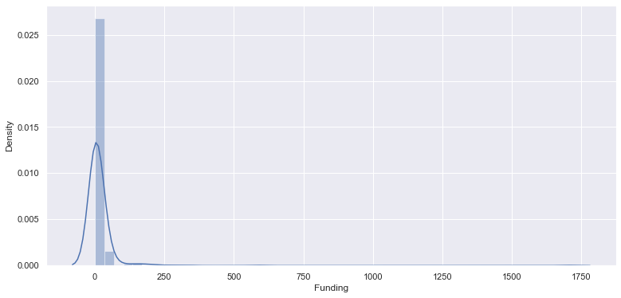

```python
ig, ax_hist = plt.subplots(figsize = (12.8, 6))
sns.distplot(df3.Funding)

# the spread of data is very uneven. We have great outliers present in our dataset.
```

```python
x=df3[df3['Funding']>100].index
```

```python
median = np.median(df3['Funding'])
Q3 = df3['Funding'].quantile(0.75)
Q1 = df3['Funding'].quantile(0.25)
print('Q1 and Q3',Q1,'and',Q3)

IQR = Q3-Q1
print('IQR is',IQR)
```

```
Q1 and Q3 0.74575 and 9.725
IQR is 8.97925
```

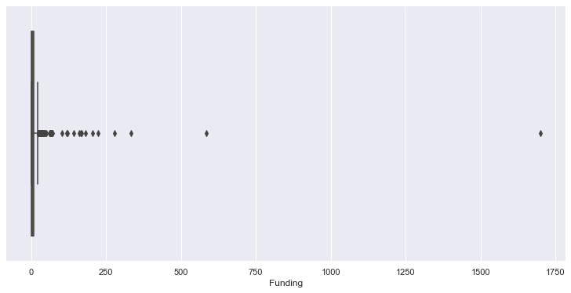

```python
plt.figure(figsize = (12.8 , 6))
sns.boxplot(df3['Funding'], palette = 'copper')
```

```python
#Lower fence = Q1 – (1.5 * IQR).
l_fence = Q1 - (1.5*IQR)
print('lower fence is: ',l_fence)
```

```
lower fence is:  -12.723125000000001
```

```python
#upper fence = Q3 + (1.5 * IQR).
u_fence = Q3 + (1.5*IQR)
print('upper fence is: ',u_fence)
```

```
upper fence is:  23.193875
```

```python
# dropping values that are greater than upper fence
y = df3[df3['Funding'] > u_fence].index
y
```

```
Int64Index([  6,  31,  40,  49,  56, 108, 113, 128, 130, 132, 138, 139, 154,
            166, 172, 179, 180, 188, 191, 209, 213, 215, 225, 231, 271, 276,
            279, 282, 302, 305, 313, 325, 346, 389, 393, 394, 398, 427, 432,
            435, 460, 471, 546, 555, 560, 581, 593, 598, 606, 615, 625, 643,
            644, 647, 649, 650, 654, 656, 659, 661],
           dtype='int64')
```

```python
df3.drop(y, inplace=True)
df3
```

|  | Startup | Product | Funding | Event | Result | OperatingState |
| --- | --- | --- | --- | --- | --- | --- |
| 1 | 3DLT | 3dlt.com | 0.630 | Disrupt NYC 2013 | Contestant | Closed |
| 3 | 3Dprintler | 3dprintler.com | 1.000 | Disrupt NY 2016 | Audience choice | Operating |
| 5 | 5to1 | 5to1.com | 19.300 | TC50 2009 | Contestant | Acquired |
| 10 | AdhereTech | adheretech.com | 1.800 | Hardware Battlefield 2014 | Contestant | Operating |
| 11 | AdRocket | adrocket.com | 1.000 | TC50 2008 | Contestant | Closed |
| ... | ... | ... | ... | ... | ... | ... |
| 642 | Xendo | xendo.com | 0.028 | Disrupt SF 2014 | Contestant | Acquired |
| 645 | Yap | yapme.com | 10.000 | TC40 2007 | Contestant | Closed |
| 646 | YayPay Inc | yaypay.com | 0.900 | Disrupt London 2015 | Contestant | Operating |
| 657 | Zivity | zivity.com | 8.000 | TC40 2007 | Contestant | Operating |
| 660 | Zula | zulaapp.com | 3.400 | Disrupt SF 2013 | Audience choice | Operating |

380 rows × 6 columns

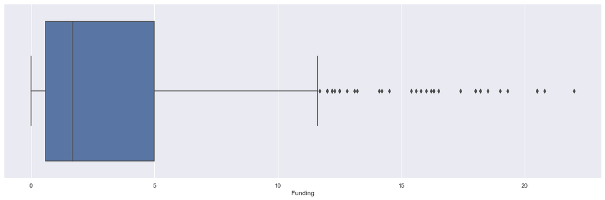

```python
plt.figure(figsize = (20 , 6))
sns.boxplot(df3['Funding'])
```

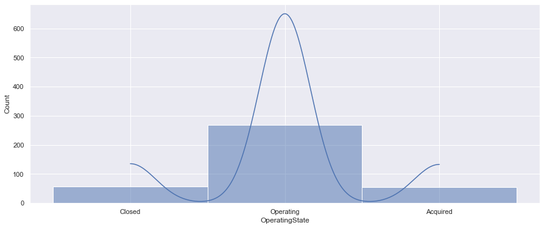

```python
# frequency count for OperatingState
plt.figure(figsize = (15 , 6))
sns.histplot(df3['OperatingState'],kde=True)
```

```python
df3['OperatingState'].value_counts()
```

```
Operating    269
Closed        56
Acquired      55
Name: OperatingState, dtype: int64
```

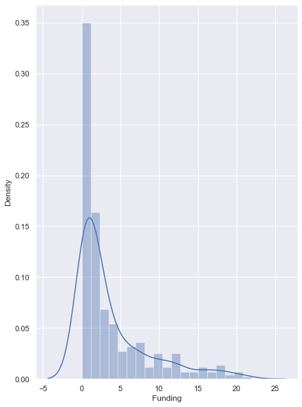

```python
fig=plt.figure(figsize = (15,10))
sns.distplot(df3['Funding'],kde=True,ax=fig.add_subplot(122))
```

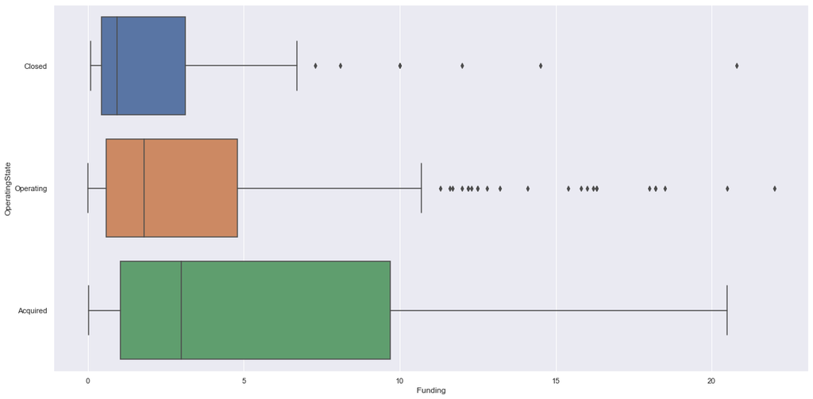

```python
plt.figure(figsize = (20 , 10))
sns.boxplot(x='Funding', y= df3['OperatingState'],data=df3)
```

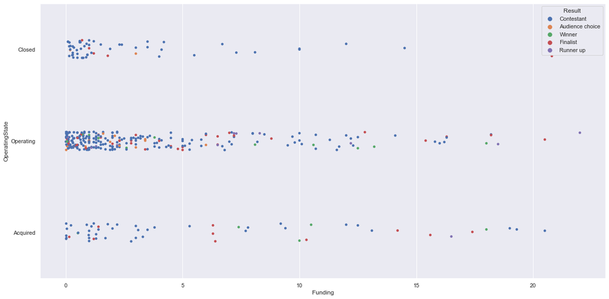

```python
plt.figure(figsize = (20 , 10))
sns.stripplot(x='Funding', y='OperatingState',data=df3,hue='Result')
```

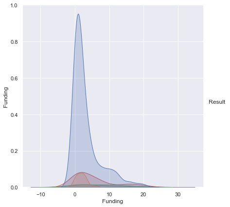

```python
sns.pairplot(df3, hue='Result',size=6,aspect=1)
```

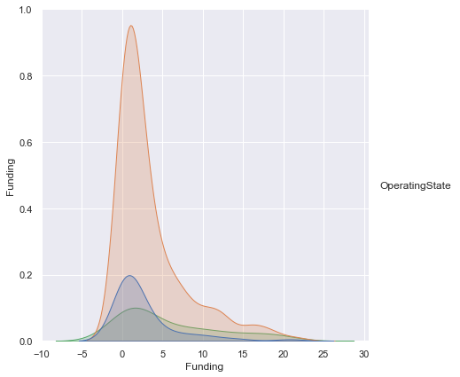

```python
sns.pairplot(df3, hue='OperatingState',size=6,aspect=1)
```

```python
df4 = df3[df3['OperatingState']!='Acquired']
df4
```

|  | Startup | Product | Funding | Event | Result | OperatingState |
| --- | --- | --- | --- | --- | --- | --- |
| 1 | 3DLT | 3dlt.com | 0.63 | Disrupt NYC 2013 | Contestant | Closed |
| 3 | 3Dprintler | 3dprintler.com | 1.00 | Disrupt NY 2016 | Audience choice | Operating |
| 10 | AdhereTech | adheretech.com | 1.80 | Hardware Battlefield 2014 | Contestant | Operating |
| 11 | AdRocket | adrocket.com | 1.00 | TC50 2008 | Contestant | Closed |
| 13 | Agrilyst | agrilyst.com | 1.00 | Disrupt SF 2015 | Winner | Operating |
| ... | ... | ... | ... | ... | ... | ... |
| 641 | Workspot | workspot.com | 15.80 | Disrupt NYC 2013 | Contestant | Operating |
| 645 | Yap | yapme.com | 10.00 | TC40 2007 | Contestant | Closed |
| 646 | YayPay Inc | yaypay.com | 0.90 | Disrupt London 2015 | Contestant | Operating |
| 657 | Zivity | zivity.com | 8.00 | TC40 2007 | Contestant | Operating |
| 660 | Zula | zulaapp.com | 3.40 | Disrupt SF 2013 | Audience choice | Operating |

325 rows × 6 columns

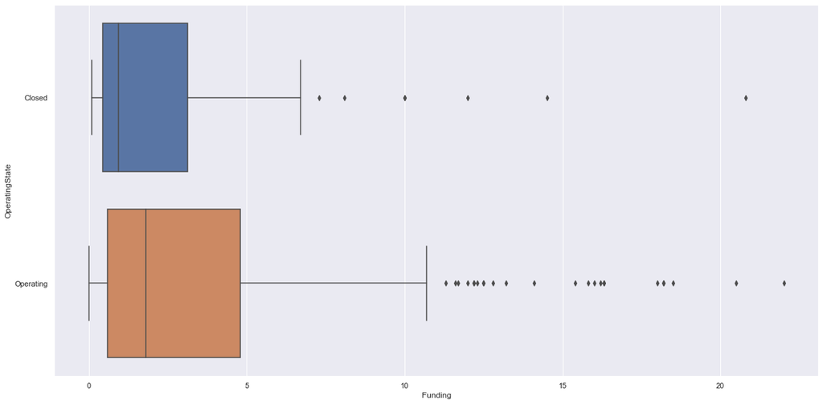

```python
plt.figure(figsize = (20 , 10))
sns.boxplot(x='Funding', y= df4['OperatingState'],data=df4)
```

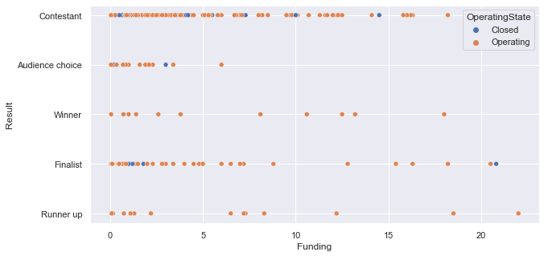

```python
plt.figure(figsize = (10 , 5))
sns.scatterplot(x='Funding',y='Result',data=df4,hue='OperatingState')
```

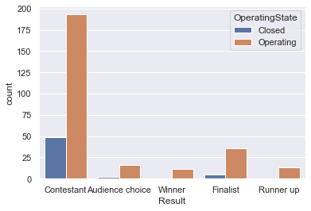

```python
sns.countplot(x='Result',data=df4,hue='OperatingState')
```

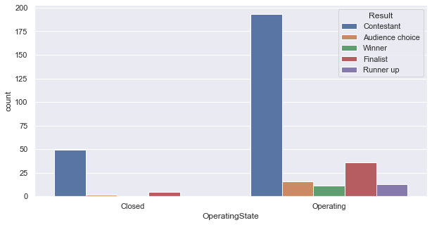

```python
plt.figure(figsize = (10 , 5))
sns.countplot(x='OperatingState',data=df4,hue='Result')
```

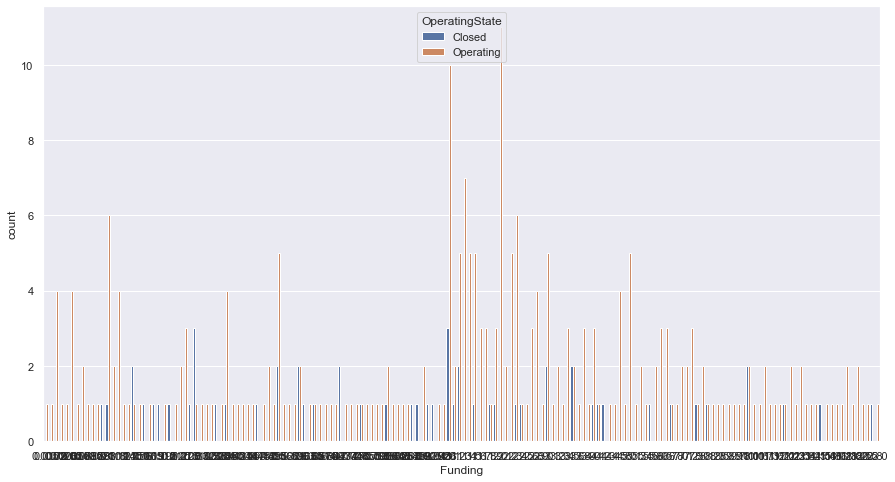

```python
plt.figure(figsize = (15 , 8))
sns.countplot(x='Funding',data=df4,hue='OperatingState')
```

#### 4. Statistical analysis:

- Is there any significant difference between Funds raised by companies that are still operating vs companies that closed down?

  ```
    Write the null hypothesis and alternative hypothesis.
    Test for significance and conclusion
  ```

- Make a copy of the original data frame.
- Check frequency distribution of Result variable.
- Calculate percentage of winners that are still operating and percentage of contestants that are still operating
- Write your hypothesis comparing the proportion of companies that are operating between winners and contestants:

  ```
    Write the null hypothesis and alternative hypothesis.
    Test for significance and conclusion
  ```

- Check distribution of the Event variable.
- Select only the Event that has disrupt keyword from 2013 onwards.
- Write and perform your hypothesis along with significance test comparing the funds raised by companies across NY, SF and EU events from 2013 onwards.
- Plot the distribution plot comparing the 3 city events.

#### Hyposthesis 1:

- H0: There is no significant difference between the Mean Funds raised by Operativg vs Closed companies.
- H1: There is significant difference between the Mean Funds raised by Operating vs Closed companies.

  To check for the significane, we'll use T-Test.  
  T-test:  
  A t-test is a type of inferential statistic which is used to determine if there is a signifi cant differencebetween the means of two groups which may be related in certain features.

```python
df3.head(5)
```

|  | Startup | Product | Funding | Event | Result | OperatingState |
| --- | --- | --- | --- | --- | --- | --- |
| 1 | 3DLT | 3dlt.com | 0.63 | Disrupt NYC 2013 | Contestant | Closed |
| 3 | 3Dprintler | 3dprintler.com | 1.00 | Disrupt NY 2016 | Audience choice | Operating |
| 5 | 5to1 | 5to1.com | 19.30 | TC50 2009 | Contestant | Acquired |
| 10 | AdhereTech | adheretech.com | 1.80 | Hardware Battlefield 2014 | Contestant | Operating |
| 11 | AdRocket | adrocket.com | 1.00 | TC50 2008 | Contestant | Closed |

```python
df3.groupby('OperatingState').mean()
```

| OperatingState | Funding |
| --- | --- |
| Acquired | 5.822745 |
| Closed | 2.682423 |
| Operating | 3.564247 |

```python
F_operatingC = np.array(df3[df3['OperatingState']=='Operating']['Funding'])
F_closedC = np.array(df3[df3['OperatingState']=='Closed']['Funding'])

print('Mean value of Funds from Operating company',format(F_operatingC.mean().round(2)))
print('Mean value of Funds from Closed company',format(F_closedC.mean().round(2)))
```

```
Mean value of Funds from Operating company 3.56
Mean value of Funds from Closed company 2.68
```

```python
#performing t-test
t, p_value = stats.ttest_ind(F_operatingC, F_closedC, axis = 0)

if p_value < 0.05:
    print(f'With the p-value as {p_value}, the difference is significant. Hence we reject the null Hypothesis.')
else:
    print(f'With the p-value as {p_value}, the difference is not significant.\nHence we fail to reject the null Hypothesis.')
```

```
With the p-value as 0.17323253726359678, the difference is not significant.
Hence we fail to reject the null Hypothesis.
```

```python
# making copy of orignal data frame
df3_1 = df3
df3_1.info()
```

```
<class 'pandas.core.frame.DataFrame'>
Int64Index: 380 entries, 1 to 660
Data columns (total 6 columns):
 #   Column          Non-Null Count  Dtype
---  ------          --------------  -----
 0   Startup         380 non-null    object
 1   Product         380 non-null    object
 2   Funding         380 non-null    float64
 3   Event           380 non-null    object
 4   Result          380 non-null    object
 5   OperatingState  380 non-null    object
dtypes: float64(1), object(5)
memory usage: 30.8+ KB
```

```python
#Check frequency distribution of Result variable.
df3_1['Result'].value_counts()
```

```
Contestant         281
Finalist            51
Audience choice     18
Winner              16
Runner up           14
Name: Result, dtype: int64
```

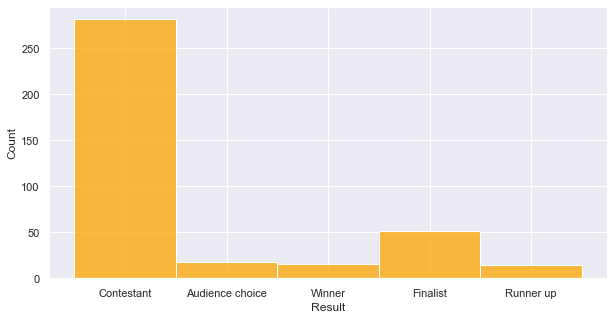

```python
plt.figure(figsize = (10 , 5))
sns.histplot(df3_1['Result'],color='orange')
```

```python
df4 = df3_1[df3_1['OperatingState']=='Operating']
t = df4.Result.count()
t
```

```
269
```

```python
df4_1 = df4.groupby('Result').describe()
df4_1
```

| Result | Funding count | Funding mean | Funding std | Funding min | Funding 25% | Funding 50% | Funding 75% | Funding max |
| --- | --- | --- | --- | --- | --- | --- | --- | --- |
| Audience choice | 16.0 | 1.935894 | 1.541590 | 0.0200 | 0.810075 | 1.95 | 2.475 | 6.0 |
| Contestant | 193.0 | 3.078249 | 3.883478 | 0.0050 | 0.500000 | 1.50 | 4.000 | 18.2 |
| Finalist | 36.0 | 4.837428 | 5.452307 | 0.0500 | 0.810100 | 2.90 | 6.500 | 20.5 |
| Runner up | 13.0 | 6.737438 | 7.127276 | 0.0857 | 1.100000 | 6.50 | 8.300 | 22.0 |
| Winner | 11.0 | 6.542909 | 6.214747 | 0.0550 | 1.200000 | 3.80 | 11.550 | 18.0 |

```python
# Percentage of Winner and contestant that are still operating:
w_t = df4['Result'][df4['Result']=='Winner'].count()
w_percent = (w_t/t)*100
print('Percentage of Winners that are still Operating: ',w_percent)

c_t = df4['Result'][df4['Result']=='Contestant'].count()
c_percent = (c_t/t)*100
print('Percentage of Contestant that are still Operating: ',c_percent)
```

```
Percentage of Winners that are still Operating:  4.089219330855019
Percentage of Contestant that are still Operating:  71.74721189591078
```

##### Write your hypothesis comparing the proportion of companies that are operating between winners and contestants:

- Write the null hypothesis and alternative hypothesis.
- Test for significance and conclusion

H0 = Proportion of companies that are operating between Winner and Contestant are equal.  
H1 = Proportion of companies that are operating between Winner and Contestant are not equal.

```python
print('Number of companies that are operating as Winner :',w_t)
print('Number of companies that are operating as Contestant :',c_t)

w_c = df3_1['Result'][df3_1['Result']=='Winner'].count()
print('\nNumber of companies as Winner',w_c)
c_c = df3_1['Result'][df3_1['Result']=='Contestant'].count()
print('Number of companies as Contestant',c_c)
```

```
Number of companies that are operating as Winner : 11
Number of companies that are operating as Contestant : 193

Number of companies as Winner 16
Number of companies as Contestant 281
```

```python
print('Proportion of Operating Companies in Winner :',round(w_t/w_c,3))
print('Proportion of Operating Companies in Contestant :',round(c_t/c_c,3))
```

```
Proportion of Operating Companies in Winner : 0.688
Proportion of Operating Companies in Contestant : 0.687
```

```python
#not much difference can be seen in the values, lets compare using statistical tool:

from statsmodels.stats.proportion import proportions_ztest

stat, p_value = proportions_ztest([w_t, c_t] , [w_c, c_c])

if p_value < 0.05:
    print(f'With a p-value of {round(p_value, 4)} the difference is significant.|We reject the null|')
    print('Proportion of Operating companies between Winner and Contestant is significant.')
else:
    print(f'With a p-value of {round(p_value, 4)} the difference is not significant. so,\n|---We failed to reject the null hypothesis---|')
    print('Proportion of Operating companies between Winner and Contestant is not significant.')
# the results of test, explians the same result that we found earlier
```

```
With a p-value of 0.9955 the difference is not significant. so,
|---We failed to reject the null hypothesis---|
Proportion of Operating companies between Winner and Contestant is not significant.
```

```
Event is defined as:
 TC50 2008                    25
TC40 2007                    22
Disrupt NY 2015              21
Disrupt SF 2011              19
TC50 2009                    19
Disrupt NYC 2013             19
Disrupt SF 2014              19
Disrupt NYC 2012             19
Disrupt SF 2013              19
Disrupt SF 2015              19
Disrupt SF 2016              17
Disrupt NY 2016              16
Disrupt NYC 2014             15
Disrupt NYC 2011             15
Disrupt SF 2012              15
Disrupt SF 2010              13
Hardware Battlefield 2014    12
Hardware Battlefield 2016    12
Disrupt London 2015          11
Disrupt NYC 2010             10
Disrupt London 2016          10
Hardware Battlefield 2015    10
Disrupt EU 2014              10
Disrupt EU 2013               9
Disrupt Beijing 2011          4
Name: Event, dtype: int64
```

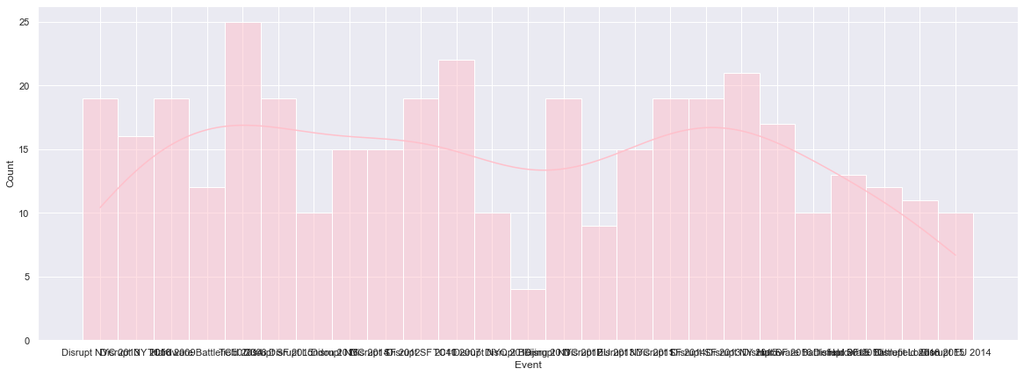

```python
# Check distribution of the Event variable.
print('Event is defined as:\n',df3_1['Event'].value_counts())
plt.figure(figsize = (20 , 7))
sns.histplot(df3_1['Event'],color='pink',kde=True)
```

```python
df3_1.head(10)
```

|  | Startup | Product | Funding | Event | Result | OperatingState |
| --- | --- | --- | --- | --- | --- | --- |
| 1 | 3DLT | 3dlt.com | 0.6300 | Disrupt NYC 2013 | Contestant | Closed |
| 3 | 3Dprintler | 3dprintler.com | 1.0000 | Disrupt NY 2016 | Audience choice | Operating |
| 5 | 5to1 | 5to1.com | 19.3000 | TC50 2009 | Contestant | Acquired |
| 10 | AdhereTech | adheretech.com | 1.8000 | Hardware Battlefield 2014 | Contestant | Operating |
| 11 | AdRocket | adrocket.com | 1.0000 | TC50 2008 | Contestant | Closed |
| 13 | Agrilyst | agrilyst.com | 1.0000 | Disrupt SF 2015 | Winner | Operating |
| 14 | Aiden | aiden.ai | 0.7500 | Disrupt London 2016 | Contestant | Operating |
| 15 | AirBoxLab | foobot.io | 0.0179 | Hardware Battlefield 2014 | Contestant | Operating |
| 16 | Aircall | aircall.io | 11.6000 | Disrupt SF 2015 | Contestant | Operating |
| 17 | AirDroids | airdroids.com | 0.9292 | Hardware Battlefield 2014 | Contestant | Closed |

```python
df3_2 = df3_1
```

```python
df3_2['Year'] = df3_2['Event'].str[-4:]
```

```python
df3_2.info()
```

[output not shown]

```python
df3_2['Year'] = df3_2['Year'].astype(int)
```

```python
x = df3_2[df3_2['Year'] < 2013].index
x
```

[output not shown]

```python
df3_2.drop(x, inplace=True)
df3_2
```

|  | Startup | Product | Funding | Event | Result | OperatingState | Year |
| --- | --- | --- | --- | --- | --- | --- | --- |
| 1 | 3DLT | 3dlt.com | 0.630 | Disrupt NYC 2013 | Contestant | Closed | 2013 |
| 3 | 3Dprintler | 3dprintler.com | 1.000 | Disrupt NY 2016 | Audience choice | Operating | 2016 |
| 10 | AdhereTech | adheretech.com | 1.800 | Hardware Battlefield 2014 | Contestant | Operating | 2014 |
| 13 | Agrilyst | agrilyst.com | 1.000 | Disrupt SF 2015 | Winner | Operating | 2015 |
| 14 | Aiden | aiden.ai | 0.750 | Disrupt London 2016 | Contestant | Operating | 2016 |
| ... | ... | ... | ... | ... | ... | ... | ... |
| 638 | Wiivv | wiivv.com | 12.200 | Hardware Battlefield 2016 | Runner up | Operating | 2016 |
| 641 | Workspot | workspot.com | 15.800 | Disrupt NYC 2013 | Contestant | Operating | 2013 |
| 642 | Xendo | xendo.com | 0.028 | Disrupt SF 2014 | Contestant | Acquired | 2014 |
| 646 | YayPay Inc | yaypay.com | 0.900 | Disrupt London 2015 | Contestant | Operating | 2015 |
| 660 | Zula | zulaapp.com | 3.400 | Disrupt SF 2013 | Audience choice | Operating | 2013 |

219 rows × 7 columns

```python
df3_2['Year'].describe()
```

```
count     219.000000
mean     2014.566210
std         1.087439
min      2013.000000
25%      2014.000000
50%      2015.000000
75%      2015.500000
max      2016.000000
Name: Year, dtype: float64
```

```python
df3_2['Event_1'] = df3_2['Event'].str[:7]
df3_2
```

|  | Startup | Product | Funding | Event | Result | OperatingState | Year | Event_1 |
| --- | --- | --- | --- | --- | --- | --- | --- | --- |
| 1 | 3DLT | 3dlt.com | 0.630 | Disrupt NYC 2013 | Contestant | Closed | 2013 | Disrupt |
| 3 | 3Dprintler | 3dprintler.com | 1.000 | Disrupt NY 2016 | Audience choice | Operating | 2016 | Disrupt |
| 10 | AdhereTech | adheretech.com | 1.800 | Hardware Battlefield 2014 | Contestant | Operating | 2014 | Hardwar |
| 13 | Agrilyst | agrilyst.com | 1.000 | Disrupt SF 2015 | Winner | Operating | 2015 | Disrupt |
| 14 | Aiden | aiden.ai | 0.750 | Disrupt London 2016 | Contestant | Operating | 2016 | Disrupt |
| ... | ... | ... | ... | ... | ... | ... | ... | ... |
| 638 | Wiivv | wiivv.com | 12.200 | Hardware Battlefield 2016 | Runner up | Operating | 2016 | Hardwar |
| 641 | Workspot | workspot.com | 15.800 | Disrupt NYC 2013 | Contestant | Operating | 2013 | Disrupt |
| 642 | Xendo | xendo.com | 0.028 | Disrupt SF 2014 | Contestant | Acquired | 2014 | Disrupt |
| 646 | YayPay Inc | yaypay.com | 0.900 | Disrupt London 2015 | Contestant | Operating | 2015 | Disrupt |
| 660 | Zula | zulaapp.com | 3.400 | Disrupt SF 2013 | Audience choice | Operating | 2013 | Disrupt |

219 rows × 8 columns

```python
y = df3_2[df3_2['Event_1'] != 'Disrupt'].index
y
```

```
Int64Index([ 10,  15,  17,  44,  65,  73,  87,  89, 153, 161, 200, 204, 214,
            239, 263, 278, 296, 314, 326, 354, 372, 374, 409, 463, 478, 479,
            480, 484, 504, 534, 552, 567, 623, 638],
           dtype='int64')
```

```python
df3_2.drop(y, inplace=True)
df3_2
```

|  | Startup | Product | Funding | Event | Result | OperatingState | Year | Event_1 |
| --- | --- | --- | --- | --- | --- | --- | --- | --- |
| 1 | 3DLT | 3dlt.com | 0.630 | Disrupt NYC 2013 | Contestant | Closed | 2013 | Disrupt |
| 3 | 3Dprintler | 3dprintler.com | 1.000 | Disrupt NY 2016 | Audience choice | Operating | 2016 | Disrupt |
| 13 | Agrilyst | agrilyst.com | 1.000 | Disrupt SF 2015 | Winner | Operating | 2015 | Disrupt |
| 14 | Aiden | aiden.ai | 0.750 | Disrupt London 2016 | Contestant | Operating | 2016 | Disrupt |
| 16 | Aircall | aircall.io | 11.600 | Disrupt SF 2015 | Contestant | Operating | 2015 | Disrupt |
| ... | ... | ... | ... | ... | ... | ... | ... | ... |
| 635 | Welltwigs | welltwigs.com | 0.050 | Disrupt NY 2015 | Contestant | Operating | 2015 | Disrupt |
| 641 | Workspot | workspot.com | 15.800 | Disrupt NYC 2013 | Contestant | Operating | 2013 | Disrupt |
| 642 | Xendo | xendo.com | 0.028 | Disrupt SF 2014 | Contestant | Acquired | 2014 | Disrupt |
| 646 | YayPay Inc | yaypay.com | 0.900 | Disrupt London 2015 | Contestant | Operating | 2015 | Disrupt |
| 660 | Zula | zulaapp.com | 3.400 | Disrupt SF 2013 | Audience choice | Operating | 2013 | Disrupt |

185 rows × 8 columns

```python
# our df3_2 now has only the Event that has disrupt keyword from 2013 onwards.
```

```python
# creating dataframe where we have only SF/NY/EU data.

str_s = ['SF','NY','NYC','EU']

df5 = df3_2[df3_2['Event'].str.contains('|'.join(str_s))]
df5
```

|  | Startup | Product | Funding | Event | Result | OperatingState | Year | Event_1 |
| --- | --- | --- | --- | --- | --- | --- | --- | --- |
| 1 | 3DLT | 3dlt.com | 0.630 | Disrupt NYC 2013 | Contestant | Closed | 2013 | Disrupt |
| 3 | 3Dprintler | 3dprintler.com | 1.000 | Disrupt NY 2016 | Audience choice | Operating | 2016 | Disrupt |
| 13 | Agrilyst | agrilyst.com | 1.000 | Disrupt SF 2015 | Winner | Operating | 2015 | Disrupt |
| 16 | Aircall | aircall.io | 11.600 | Disrupt SF 2015 | Contestant | Operating | 2015 | Disrupt |
| 18 | AirHelp | airhelp.com | 12.200 | Disrupt NYC 2014 | Contestant | Operating | 2014 | Disrupt |
| ... | ... | ... | ... | ... | ... | ... | ... | ... |
| 634 | Wellthy | wellthy.com | 2.000 | Disrupt SF 2015 | Contestant | Operating | 2015 | Disrupt |
| 635 | Welltwigs | welltwigs.com | 0.050 | Disrupt NY 2015 | Contestant | Operating | 2015 | Disrupt |
| 641 | Workspot | workspot.com | 15.800 | Disrupt NYC 2013 | Contestant | Operating | 2013 | Disrupt |
| 642 | Xendo | xendo.com | 0.028 | Disrupt SF 2014 | Contestant | Acquired | 2014 | Disrupt |
| 660 | Zula | zulaapp.com | 3.400 | Disrupt SF 2013 | Audience choice | Operating | 2013 | Disrupt |

164 rows × 8 columns

```python
df5[['one','City','three']] = df5.Event.str.split(expand=True)
df5
```

|  | Startup | Product | Funding | Event | Result | OperatingState | Year | Event_1 | one | City | three |
| --- | --- | --- | --- | --- | --- | --- | --- | --- | --- | --- | --- |
| 1 | 3DLT | 3dlt.com | 0.630 | Disrupt NYC 2013 | Contestant | Closed | 2013 | Disrupt | Disrupt | NYC | 2013 |
| 3 | 3Dprintler | 3dprintler.com | 1.000 | Disrupt NY 2016 | Audience choice | Operating | 2016 | Disrupt | Disrupt | NY | 2016 |
| 13 | Agrilyst | agrilyst.com | 1.000 | Disrupt SF 2015 | Winner | Operating | 2015 | Disrupt | Disrupt | SF | 2015 |
| 16 | Aircall | aircall.io | 11.600 | Disrupt SF 2015 | Contestant | Operating | 2015 | Disrupt | Disrupt | SF | 2015 |
| 18 | AirHelp | airhelp.com | 12.200 | Disrupt NYC 2014 | Contestant | Operating | 2014 | Disrupt | Disrupt | NYC | 2014 |
| ... | ... | ... | ... | ... | ... | ... | ... | ... | ... | ... | ... |
| 634 | Wellthy | wellthy.com | 2.000 | Disrupt SF 2015 | Contestant | Operating | 2015 | Disrupt | Disrupt | SF | 2015 |
| 635 | Welltwigs | welltwigs.com | 0.050 | Disrupt NY 2015 | Contestant | Operating | 2015 | Disrupt | Disrupt | NY | 2015 |
| 641 | Workspot | workspot.com | 15.800 | Disrupt NYC 2013 | Contestant | Operating | 2013 | Disrupt | Disrupt | NYC | 2013 |
| 642 | Xendo | xendo.com | 0.028 | Disrupt SF 2014 | Contestant | Acquired | 2014 | Disrupt | Disrupt | SF | 2014 |
| 660 | Zula | zulaapp.com | 3.400 | Disrupt SF 2013 | Audience choice | Operating | 2013 | Disrupt | Disrupt | SF | 2013 |

164 rows × 11 columns

```python
u=['Event_1','one','three']
df5.drop(columns=u, inplace=True)
```

```python
df5['City'] = df5['City'].replace('NYC','NY')
```

```python
df5
```

|  | Startup | Product | Funding | Event | Result | OperatingState | Year | City |
| --- | --- | --- | --- | --- | --- | --- | --- | --- |
| 1 | 3DLT | 3dlt.com | 0.630 | Disrupt NYC 2013 | Contestant | Closed | 2013 | NY |
| 3 | 3Dprintler | 3dprintler.com | 1.000 | Disrupt NY 2016 | Audience choice | Operating | 2016 | NY |
| 13 | Agrilyst | agrilyst.com | 1.000 | Disrupt SF 2015 | Winner | Operating | 2015 | SF |
| 16 | Aircall | aircall.io | 11.600 | Disrupt SF 2015 | Contestant | Operating | 2015 | SF |
| 18 | AirHelp | airhelp.com | 12.200 | Disrupt NYC 2014 | Contestant | Operating | 2014 | NY |
| ... | ... | ... | ... | ... | ... | ... | ... | ... |
| 634 | Wellthy | wellthy.com | 2.000 | Disrupt SF 2015 | Contestant | Operating | 2015 | SF |
| 635 | Welltwigs | welltwigs.com | 0.050 | Disrupt NY 2015 | Contestant | Operating | 2015 | NY |
| 641 | Workspot | workspot.com | 15.800 | Disrupt NYC 2013 | Contestant | Operating | 2013 | NY |
| 642 | Xendo | xendo.com | 0.028 | Disrupt SF 2014 | Contestant | Acquired | 2014 | SF |
| 660 | Zula | zulaapp.com | 3.400 | Disrupt SF 2013 | Audience choice | Operating | 2013 | SF |

164 rows × 8 columns

```python
t=df5[['City','Funding']].groupby('City')
```

```python
t.describe().T
```

|  | City | EU | NY | SF |
| --- | --- | --- | --- | --- |
| Funding | count | 19.000000 | 71.000000 | 74.000000 |
|  | mean | 3.559732 | 3.605079 | 2.962930 |
|  | std | 4.885227 | 4.640688 | 3.505991 |
|  | min | 0.275000 | 0.020000 | 0.020000 |
|  | 25% | 0.455750 | 0.510000 | 0.525000 |
|  | 50% | 1.100000 | 1.600000 | 1.600000 |
|  | 75% | 6.050000 | 5.900000 | 3.275000 |
|  | max | 18.200000 | 22.000000 | 12.500000 |

```python
# funds raised by companies in event EU, NY and SF
```

```python
Funds_EU = np.array(df5[df5['City']=='EU']['Funding']).sum().round(2)
print('Funds generated by companies in EU event:',Funds_EU)

Funds_SF = np.array(df5[df5['City']=='SF']['Funding']).sum().round(2)
print('Funds generated by companies in SF event:',Funds_SF)

Funds_NY = np.array(df5[df5['City']=='NY']['Funding']).sum().round(2)
print('Funds generated by companies in NY event:',Funds_NY)
```

```
Funds generated by companies in EU event: 67.63
Funds generated by companies in SF event: 219.26
Funds generated by companies in NY event: 255.96
```

- Write and perform your hypothesis along with significance test comparing the funds raised by companies across NY, SF and EU events from 2013 onwards.

Hypothesis 3:

- H0: All pair of samples are same. i.e --> The means of the Funds generated in 3 cities are equal.
- H1: Atleast one pair of sample is significantly different. i.e.--> Difference in between any one pair of means of Funds.

To perform the analysis, we'll use ANOVA: to compare the diff erence between the three or more samples/groups ofa single independent variable.

```python
# calculating the mean of Funds collected by companies form events in EU, SF and NY


Funds_EU = np.array(df5[df5['City']=='EU']['Funding']).mean().round(2)
print('Mean Funds generated by companies in EU event:',Funds_EU)

Funds_SF = np.array(df5[df5['City']=='SF']['Funding']).mean().round(2)
print('Mean Funds generated by companies in SF event:',Funds_SF)

Funds_NY = np.array(df5[df5['City']=='NY']['Funding']).mean().round(2)
print('Mean Funds generated by companies in NY event:',Funds_NY)
```

```
Mean Funds generated by companies in EU event: 3.56
Mean Funds generated by companies in SF event: 2.96
Mean Funds generated by companies in NY event: 3.61
```

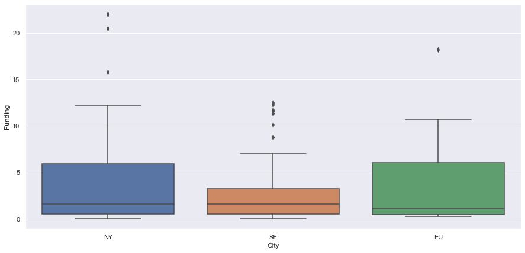

```python
# One quick EDA check on our data:
plt.figure(figsize = (15 , 7))
sns.boxplot(x='City',y='Funding',data=df5)
```

```python
# Performing Anova test:
import statsmodels.api         as     sm
from   statsmodels.formula.api import ols

anova = df5[['City','Funding']]
anova
```

|  | City | Funding |
| --- | --- | --- |
| 1 | NY | 0.630 |
| 3 | NY | 1.000 |
| 13 | SF | 1.000 |
| 16 | SF | 11.600 |
| 18 | NY | 12.200 |
| ... | ... | ... |
| 634 | SF | 2.000 |
| 635 | NY | 0.050 |
| 641 | NY | 15.800 |
| 642 | SF | 0.028 |
| 660 | SF | 3.400 |

164 rows × 2 columns

```python
mod = ols('Funding ~ City', data = anova).fit()
aov_table = sm.stats.anova_lm(mod, typ=2)
print(aov_table)
```

```
               sum_sq     df         F    PR(>F)
City        16.280905    2.0  0.462393  0.630608
Residual  2834.410508  161.0       NaN       NaN
```

```python
print(mod.summary())
```

```
                            OLS Regression Results
==============================================================================
Dep. Variable:                Funding   R-squared:                       0.006
Model:                            OLS   Adj. R-squared:                 -0.007
Method:                 Least Squares   F-statistic:                    0.4624
Date:                Wed, 30 Jun 2021   Prob (F-statistic):              0.631
Time:                        00:04:49   Log-Likelihood:                -466.38
No. Observations:                 164   AIC:                             938.8
Df Residuals:                     161   BIC:                             948.1
Df Model:                           2
Covariance Type:            nonrobust
==============================================================================
                 coef    std err          t      P>|t|      [0.025      0.975]
------------------------------------------------------------------------------
Intercept      3.5597      0.963      3.698      0.000       1.659       5.461
City[T.NY]     0.0453      1.084      0.042      0.967      -2.095       2.186
City[T.SF]    -0.5968      1.079     -0.553      0.581      -2.728       1.534
==============================================================================
Omnibus:                       72.791   Durbin-Watson:                   1.830
Prob(Omnibus):                  0.000   Jarque-Bera (JB):              198.179
Skew:                           1.898   Prob(JB):                     9.25e-44
Kurtosis:                       6.820   Cond. No.                         6.21
==============================================================================

Notes:
[1] Standard Errors assume that the covariance matrix of the errors is correctly specified.
```

### Here, our P score, which is 0.630 is greater than the chosen level of 0.05. Hence, it failed to reject the NULL Hypothesis.

```python
#check for the Anova test by comparing each pair.
from statsmodels.stats.multicomp import pairwise_tukeyhsd
print(pairwise_tukeyhsd(anova['Funding'], anova['City']))
```

```
Multiple Comparison of Means - Tukey HSD, FWER=0.05
===================================================
group1 group2 meandiff p-adj   lower  upper  reject
---------------------------------------------------
    EU     NY   0.0453    0.9 -2.5186 2.6093  False
    EU     SF  -0.5968 0.8282 -3.1497 1.9561  False
    NY     SF  -0.6421 0.6177 -2.2912 1.0069  False
---------------------------------------------------
```

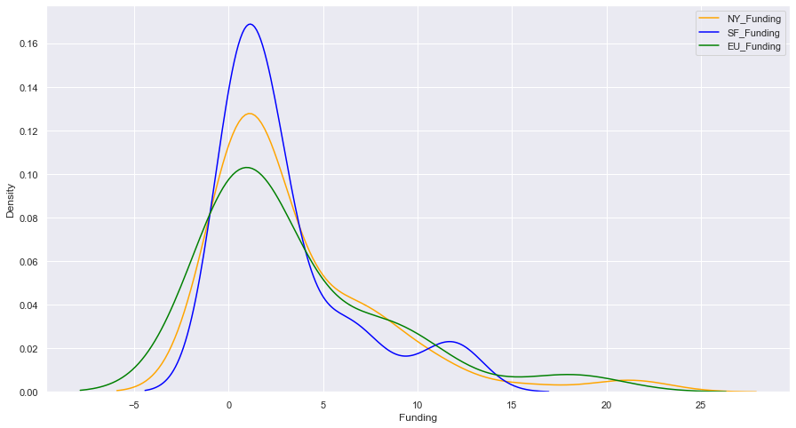

```python
# Plot the distribution plot comparing the 3 city events.
fig,ax_hist=plt.subplots(figsize=(15,8))

sns.distplot(anova[(anova['City'] == 'NY')]['Funding'],
             color = 'orange', hist = False, label = 'NY_Funding')
sns.distplot(anova[(anova['City'] == 'SF')]['Funding'],
             color = 'Blue', hist = False, label = 'SF_Funding')
sns.distplot(anova[(anova['City'] == 'EU')]['Funding'],
             color = 'Green', hist = False, label = 'EU_Funding')
plt.legend()
plt.show()
```

Write your observations on improvements or suggestions on quality, quantity, variety,  
velocity, veracity etc. on the data points collected to perform  
a better data analysis.

- The outliers of the set would have skewed the results
- Data should have been divided between event/city from start.
- While looking for data for city NY, NYC should also be considered.
- Different values of Funds could have been standerised.